# Airport Claims (R Example)

# Overview

The following example demonstrates a data science workflow from start to finish using real-world claims data collected by the Transportation Security Administration.

The data file used for this example can be obtained from https://support.sas.com/documentation/onlinedoc/viya/exampledatasets/TSAClaims2002_2017.csv. The data are originally from https://www.dhs.gov/tsa-claims-data.

# Load the SWAT Library and Connect to the CAS Server

Load the SWAT library and then create a connection to the CAS server using the CAS function and assign the CAS connection object to the variable s. The first argument specifies the host name, and the second argument specifies the port.

```r
library(swat)
s <- CAS("rdcgrd310.unx.sas.com", 10065)
```

```
## NOTE: Connecting to CAS and generating CAS action functions for loaded
##       action sets...
```

```
## NOTE: To generate the functions with signatures (for tab completion), set
##       options(cas.gen.function.sig=TRUE).
```

# Load the Data

There are two methods that can be used to load a data file. The first method is to load the data from a caslib (server-side load). The second method is to load the data from a location that is accessible to the CAS server but not associated with a caslib (client-side load).

## Load the Data from a Caslib

The default method of loading data is to load the data from the data source portion of a caslib, which is known as a server-side load. This requires the data file to be saved in the active caslib (Casuser). Once the file has been saved to the caslib, use the loadTable action to load the TSAClaims2002_2017.csv file into the Casuser caslib as an in-memory table.

```r
cas.table.loadTable(s,
                    path="TSAClaims2002_2017.csv",
                    caslib="casuser",
                    casOut=list(name="tsaclaims",
                                replace=TRUE),
                    importOptions=list(fileType="CSV",
                                       encoding="latin1",
                                       guessrows=30000))
```

```
## NOTE: Cloud Analytic Services made the file TSAClaims2002_2017.csv available as table TSACLAIMS in caslib CASUSER(gazhan).
```

```
## $caslib
## [1] "CASUSER(gazhan)"
##
## $tableName
## [1] "TSACLAIMS"
```

## Load a Client-Side Data File into CAS

Another method of loading data into CAS memory is to load the data from an external source that is accessible to the CAS server. This example uses the upload_file function to perform a client-side load.

```r
result <- cas.upload.file(s,
                          "https://support.sas.com/documentation/onlinedoc/viya/exampledatasets/TSAClaims2002_2017.csv",
                          casOut=list(name="tsaclaims",
                                      replace=TRUE),
                          importOptions=list(fileType="CSV",
                                             encoding="latin1",
                                             guessrows=300000))
```

```
## [1] "NOTE: Cloud Analytic Services made the uploaded file available as table TSACLAIMS in caslib CASUSER(gazhan)."
## [1] "NOTE: The table TSACLAIMS has been created in caslib CASUSER(gazhan) from binary data uploaded to Cloud Analytic Services."
```

# Explore the Data

## Examine the Columns

To get information about a table’s columns, use the columnInfo action on the tsaclaims table to obtain metadata about the table. The result includes the names of columns, and information about each column, including its label (if applicable), type, length, and format.

```r
cas.table.columnInfo(s,
                     table=list(caslib="casuser",
                                name="tsaclaims"))
```

```
## $ColumnInfo
##           Column Label ID    Type RawLength FormattedLength Format NFL NFD
## 1   Claim_Number        1 varchar        13              13          0   0
## 2  Date_Received        2  double         8              12          0   0
## 3  Incident_Date        3  double         8              12          0   0
## 4   Airport_Code        4 varchar         3               3          0   0
## 5   Airport_Name        5 varchar        48              48          0   0
## 6     Claim_Type        6 varchar        39              39          0   0
## 7     Claim_Site        7 varchar        15              15          0   0
## 8  Item_Category        8 varchar       834             834          0   0
## 9   Close_Amount        9  double         8              12          0   0
## 10   Disposition       10 varchar        23              23          0   0
## 11     StateName       11 varchar        17              17          0   0
## 12         State       12 varchar         2               2          0   0
## 13        County       13 varchar        20              20          0   0
## 14          City       14 varchar        33              33          0   0
```

## Examine the Rows

Preview the first few rows of the table by using the table.fetch action and specifying 10 in the to parameter. The sortBy parameter specifies that the column Close_Amount is sorted in descending order. Examine the values in the rows to identify any data issues. In the resulting table, notice that the values in the two date columns (Date_Received and Incident_Date) are 5-digit numbers and are not properly formatted in an MM-DD-YYYY format. In addition, the Close_Amount variable shows values with a missing dollar sign. The columns need to be modified to apply the appropriate date and currency formats.

```r
cas.table.fetch(s,
                table=list(caslib="casuser",
                           name="tsaclaims"),
                to=10,
                sortBy=list(list(name="Close_Amount", order="DESCENDING")))
```

```
## $Fetch
##    _Index_  Claim_Number Date_Received Incident_Date Airport_Code
## 1        1      0221037L         15757      15713.00          LAS
## 2        2 2007042424434         16520      16238.00          TSA
## 3        3      1117800M         16026      15941.00          HOU
## 4        4 2004072359942         16182      16111.00
## 5        5 2004070758620         16225      16163.00            F
## 6        6 2017092043319         21075      20948.00          ZZX
## 7        7 2014062714922         19901      19693.84          FWA
## 8        8 2004080560658         16265      15557.00          JFK
## 9        9 2012110798436         19201      18991.00          DTW
## 10      10 2006012600385         16820      16747.00          BMI
##                                 Airport_Name              Claim_Type
## 1                     McCarran International Passenger Property Loss
## 2                TSA - Non-Specified Airport         Personal Injury
```

[output cut: 30 more lines]

# Prepare the Data

## Add Formats to Variables

The next step is to add formats to the variables. Use the table.alterTable action to rename columns and apply formats to the date and amount columns. Assign new column labels to the column names so that the underscores are removed. Assign the format dollar19.2 to Close_Amount to display the formatted values with a dollar sign and two decimal places. Assign a format of mmddyy10. to the Date_Received and Incident_Date columns to display the values in the format of MM-DD-YYYY.

```r
cas.table.alterTable(s,
                     name="tsaclaims",
                     caslib="casuser",
                     columns=list(list(name="Close_Amount", format="dollar19.2"),
                                  list(name="Claim_Number", label="Claim Number"),
                                  list(name="Date_Received", label="Date Received", format="mmddyy10."),
                                  list(name="Incident_Date", label="Incident Date", format="mmddyy10."),
                                  list(name="Airport_Code", label="Airport Code"),
                                  list(name="Airport_Name", label="Airport Name"),
                                  list(name="Claim_Type", label="Claim Type"),
                                  list(name="Claim_Site", label="Claim Site"),
                                  list(name="Item_Category", label="Item Category"),
                                  list(name="Close_Amount", label="Close Amount")))
```

```
## list()
```

```r
cas.table.columnInfo(s, table="tsaclaims")
```

```
## $ColumnInfo
##           Column         Label ID    Type RawLength FormattedLength Format NFL
## 1   Claim_Number  Claim Number  1 varchar        13              13          0
## 2  Date_Received Date Received  2  double         8              12 MMDDYY  10
## 3  Incident_Date Incident Date  3  double         8              12 MMDDYY  10
## 4   Airport_Code  Airport Code  4 varchar         3               3          0
## 5   Airport_Name  Airport Name  5 varchar        48              48          0
## 6     Claim_Type    Claim Type  6 varchar        39              39          0
## 7     Claim_Site    Claim Site  7 varchar        15              15          0
## 8  Item_Category Item Category  8 varchar       834             834          0
## 9   Close_Amount  Close Amount  9  double         8              19 DOLLAR  19
## 10   Disposition               10 varchar        23              23          0
## 11     StateName               11 varchar        17              17          0
## 12         State               12 varchar         2               2          0
## 13        County               13 varchar        20              20          0
```

[output cut: 16 more lines]

The resulting table shows that the format for the Date_Received and Incident_Date columns is MMDDYY, and the Close_Amount is DOLLAR.

## Count the Number of Unique and Missing Column Values

Examine the number of unique and missing values for each variable to determine whether further cleaning is needed. Run the simple.distinct action to identify the number of distinct values and the number of missing values for each column.

```r
cas.simple.distinct(s,
                    table="tsaclaims")
```

```
## $Distinct
##           Column NDistinct NMiss Trunc
## 1   Claim_Number    220828     0     0
## 2  Date_Received      4677   260     0
## 3  Incident_Date      5739  2329     0
## 4   Airport_Code       471  8519     0
## 5   Airport_Name       477  8519     0
## 6     Claim_Type        18  7908     0
## 7     Claim_Site         9   735     0
## 8  Item_Category      4919  3961     0
## 9   Close_Amount     21490 33746     0
## 10   Disposition        13 13784     0
## 11     StateName        57 11673     0
## 12         State        57 11673     0
## 13        County       384 13414     0
## 14          City       432 11673     0
```

## Remove Duplicate Rows

Full duplicate rows that have duplicate values on all variables should be removed. The deduplicate action removes rows that contain duplicated values on the variables listed in the groupBy parameter.

```r
cas.builtins.loadActionSet(s, actionSet="deduplication")
```

```
## NOTE: Added action set 'deduplication'.
```

```
## NOTE: Information for action set 'deduplication':
```

```
## NOTE:    deduplication
```

```
## NOTE:       deduplicate - Eliminates rows that have duplicate or unique group-by variable values
```

```
## $actionset
## [1] "deduplication"
```

```r
cas.deduplication.deduplicate(s,
                              table=list(caslib="casuser",
                                         name="tsaclaims",
                                         groupBy=list(
                                           list(name="Claim_Number"),
                                           list(name="Date_Received"),
                                           list(name="Incident_Date"),
                                           list(name="Airport_Code"),
                                           list(name="Airport_Name"),
                                           list(name="Claim_Type"),
                                           list(name="Claim_Site"),
                                           list(name="Item_Category"),
                                           list(name="Close_Amount"),
                                           list(name="Disposition"),
                                           list(name="StateName"),
                                           list(name="State"),
                                           list(name="County"),
                                           list(name="City"))),
                              casOut=list(caslib="casuser",
                                          name="tsaclaims_nodups",
                                          replace=TRUE),
                              duplicateOut=list(caslib="casuser",
                                                name="tsaclaims_dups",
                                                replace=TRUE),
                              noDuplicateKeys=TRUE)
```

```
## NOTE: There were 220855 rows read from the table TSACLAIMS.
```

```
## NOTE: The table tsaclaims_nodups has 220850 rows and 14 columns.
```

```
## NOTE: The table tsaclaims_dups has 5 rows and 14 columns.
```

```
## list()
```

## Identify Data Quality Issues

```r
cas.simple.freq(s,
                table=list(caslib="casuser",
                           name="tsaclaims_nodups"),
                inputs=list(list(name="Claim_Site"),
                            list(name="Disposition"),
                            list(name="Claim_Type"),
                            list(name="Date_Received", format="year4."),
                            list(name="Incident_Date", format="year4."),
                            list(name="State"),
                            list(name="StateName")))
```

```
## $Frequency
##            Column NumVar                                 CharVar
## 1      Claim_Site    NaN
## 2      Claim_Site    NaN                                       -
## 3      Claim_Site    NaN                             Bus Station
## 4      Claim_Site    NaN                         Checked Baggage
## 5      Claim_Site    NaN                              Checkpoint
## 6      Claim_Site    NaN                           Motor Vehicle
## 7      Claim_Site    NaN                            Not Provided
## 8      Claim_Site    NaN                                   Other
## 9      Claim_Site    NaN                               Pre-Check
## 10    Disposition    NaN
## 11    Disposition    NaN                                       -
## 12    Disposition    NaN                           *Insufficient
## 13    Disposition    NaN                         Approve in Full
```

[output cut: 408 more lines]

The data contains some errors including missing values, inconsistent values and out-of-range values that can be cleaned using the table.update action.

## Replace Missing and Inconsistent Values

```r
cas.table.update(s,
                 table=list(name="tsaclaims_nodups",
                            caslib="casuser",
                            where="Claim_Site is null or Claim_Site='-'"),
                 set=list(list(var="Claim_Site", value="'Unknown'")))
```

```
## $tableName
## [1] "TSACLAIMS_NODUPS"
##
## $rowsUpdated
## [1] 1122
```

```r
cas.table.update(s,
                 table=list(name="tsaclaims_nodups",
                            caslib="casuser",
                            where="Claim_Type is null or Claim_Type='-'"),
                 set=list(list(var="Claim_Type", value="'Unknown'")))
```

```
## $tableName
## [1] "TSACLAIMS_NODUPS"
##
## $rowsUpdated
## [1] 8283
```

```r
cas.table.update(s,
                 table=list(name="tsaclaims_nodups",
                            caslib="casuser",
                            where="Claim_Type='Passenger Property Loss/Personal Injury'
                                   or Claim_Type='Passenger Property Loss/Personal Injur'"),
                 set=list(list(var="Claim_Type", value="'Passenger Property Loss'")))
```

```
## $tableName
## [1] "TSACLAIMS_NODUPS"
##
## $rowsUpdated
## [1] 21
```

```r
cas.table.update(s,
                 table=list(name="tsaclaims_nodups",
                            caslib="casuser",
                            where="Claim_Type='Property Damage/Personal Injury'"),
                 set=list(list(var="Claim_Type", value="'Property Damage'")))
```

```
## $tableName
## [1] "TSACLAIMS_NODUPS"
##
## $rowsUpdated
## [1] 14
```

```r
cas.table.update(s,
                 table=list(name="tsaclaims_nodups",
                            caslib="casuser",
                            where="Disposition is null or Disposition='-'"),
                 set=list(list(var="Disposition", value="'Unknown'")))
```

```
## $tableName
## [1] "TSACLAIMS_NODUPS"
##
## $rowsUpdated
## [1] 26545
```

```r
cas.table.update(s,
                 table=list(name="tsaclaims_nodups",
                            caslib="casuser",
                            where="Disposition='Closed: Canceled'"),
                 set=list(list(var="Disposition", value="'Closed:Canceled'")))
```

```
## $tableName
## [1] "TSACLAIMS_NODUPS"
##
## $rowsUpdated
## [1] 167
```

```r
cas.table.update(s,
                 table=list(name="tsaclaims_nodups",
                            caslib="casuser",
                            where="Disposition='losed: Contractor Claim'"),
                 set=list(list(var="Disposition", value="'Closed:Contractor Claim'")))
```

```
## $tableName
## [1] "TSACLAIMS_NODUPS"
##
## $rowsUpdated
## [1] 73
```

```r
cas.table.update(s,
                 table=list(caslib="casuser",
                            name="tsaclaims_nodups"),
                 set=list(list(var="StateName", value="propcase(StateName)")))
```

```
## $tableName
## [1] "TSACLAIMS_NODUPS"
##
## $rowsUpdated
## [1] 220850
```

## Generate a frequency distribution to examine the cleaned columns

```r
cas.simple.freq(s,
                table=list(caslib="casuser",
                           name="tsaclaims_nodups"),
                inputs=list(list(name="Claim_Site"),
                            list(name="Disposition"),
                            list(name="Claim_Type"),
                            list(name="Date_Received", format="year4."),
                            list(name="Incident_Date", format="year4.")))
```

```
## $Frequency
##           Column NumVar                 CharVar
## 1     Claim_Site    NaN             Bus Station
## 2     Claim_Site    NaN         Checked Baggage
## 3     Claim_Site    NaN              Checkpoint
## 4     Claim_Site    NaN           Motor Vehicle
## 5     Claim_Site    NaN            Not Provided
## 6     Claim_Site    NaN                   Other
## 7     Claim_Site    NaN               Pre-Check
## 8     Claim_Site    NaN                 Unknown
## 9    Disposition    NaN           *Insufficient
## 10   Disposition    NaN         Approve in Full
## 11   Disposition    NaN         Closed:Canceled
## 12   Disposition    NaN Closed:Contractor Claim
## 13   Disposition    NaN                    Deny
```

[output cut: 164 more lines]

```r
cas.simple.freq(s,
                table=list(caslib="casuser",
                           name="tsaclaims_nodups"),
                inputs=list(list(name="State"),
                            list(name="StateName")))
```

```
## $Frequency
##        Column           CharVar            FmtVar Level Frequency
## 1       State                                         1     11669
## 2       State                AK                AK     2      1637
## 3       State                AL                AL     3       755
## 4       State                AR                AR     4       537
## 5       State                AS                AS     5         1
## 6       State                AZ                AZ     6      6494
## 7       State                CA                CA     7     25306
## 8       State                CO                CO     8      5457
## 9       State                CQ                CQ     9        14
## 10      State                CT                CT    10      1146
## 11      State                DC                DC    11      6033
## 12      State                DE                DE    12         9
## 13      State                FL                FL    13     27966
```

[output cut: 101 more lines]

## Add a New Column to Identify Rows with Errors

Create a new column to identify rows that have date values that are out of range (earlier than 2002 or later than 2017). These rows will require further investigation. In the computedVars parameter, specify the name of the new column as Date_Issues. In the computedVarsProgram parameter, write a query to assign a value of ‘Needs Review’ to the Date_Issues variable if the year of the Incident_Date or Date_Received variable falls outside of the range between 2002 and 2017.

```r
cas.table.copyTable(s,
                    casOut=list(caslib="casuser",
                                name="tsaclaims_cleaned",
                                replace=TRUE),
                    table=list(caslib="casuser",
                               name="tsaclaims_nodups",
                               computedVars=list(list(name="Date_Issues",
                                                      label="Date Issues")),
                               computedVarsProgram="if year(Incident_Date) < 2002 or
                                                    year(Incident_Date) > 2017 or
                                                    year(Date_Received) < 2002 or
                                                    year(Date_Received) > 2017
                                                    then Date_Issues='Needs Review'"))
```

```
## $caslib
## [1] "CASUSER(gazhan)"
##
## $tableName
## [1] "TSACLAIMS_CLEANED"
```

```r
cas.simple.freq(s,
                table=list(caslib="casuser",
                           name="tsaclaims_cleaned"),
                inputs=list("Date_Issues"))
```

```
## $Frequency
##        Column      CharVar       FmtVar Level Frequency
## 1 Date_Issues                               1    218311
## 2 Date_Issues Needs Review Needs Review     2      2539
```

## Drop Columns

Columns that are no longer needed can be dropped using the table.alterTable action. Here the columns County and City are specified in the drop parameter.

```r
cas.table.alterTable(s,
                     caslib="casuser",
                     name="tsaclaims_cleaned",
                     drop=list("City", "County"))
```

```
## list()
```

## Examine the Cleaned Data

```r
cas.simple.freq(s,
                table=list(caslib="casuser",
                           name="tsaclaims_cleaned"),
                inputs=list("Date_Issues"))
```

```
## $Frequency
##        Column      CharVar       FmtVar Level Frequency
## 1 Date_Issues                               1    218311
## 2 Date_Issues Needs Review Needs Review     2      2539
```

```r
cas.simple.freq(s,
                table=list(caslib="casuser",
                           name="tsaclaims_cleaned"),
                inputs=list(list(name="Incident_Date",
                                 format="year4.")),
                casOut=list(caslib="casuser",
                            name="tsaclaims_cleaned_freq_date",
                            replace=TRUE))
```

```
## $OutputCasTables
##            casLib                        Name Rows Columns
## 1 CASUSER(gazhan) tsaclaims_cleaned_freq_date   21       5
```

# Analyze the Data

## Create Frequency Tables

```r
cas.simple.freq(s,
                table=list(caslib="casuser",
                           name="tsaclaims_cleaned",
                           where="StateName='Hawaii' and Date_Issues is null"),
                inputs=list("Claim_Site",
                            "Claim_Type",
                            "Disposition"),
                casOut=list(caslib="casuser",
                            name="tsaclaims_cleaned_freq_vars",
                            replace=TRUE))
```

```
## $OutputCasTables
##            casLib                        Name Rows Columns
## 1 CASUSER(gazhan) tsaclaims_cleaned_freq_vars   22       5
```

```r
cas.simple.summary(s,
                   table=list(name="tsaclaims_cleaned",
                              where="StateName='Hawaii' and Date_Issues is null"),
                   inputs=list("Close_Amount"),
                   subSet=list("N", "MEAN", "MIN", "MAX", "SUM"))
```

```
## $Summary
##         Column Min     Max    N     Mean      Sum
## 1 Close_Amount   0 5165.79 3805 74.64089 284008.6
```

## Generate Frequencies and Summary Statistics on a Subset of Data

Here the simple.freq action is used to generate frequency tables to show the number of claims for each Claim_Type, Claim_Site, and Disposition, as well as to calculate the mean, minimum, maximum, and sum of Close_Amount for claims in Hawaii that do not have date issues.

```r
cas.simple.freq(s,
                table=list(caslib="casuser",
                           name="tsaclaims_cleaned",
                           where="StateName='Hawaii' and Date_Issues is null"),
                inputs=list("Claim_Site",
                            "Claim_Type",
                            "Disposition"))
```

```
## $Frequency
##         Column                 CharVar                                  FmtVar
## 1   Claim_Site         Checked Baggage                         Checked Baggage
## 2   Claim_Site              Checkpoint                         Checkpoint
## 3   Claim_Site           Motor Vehicle                         Motor Vehicle
## 4   Claim_Site                   Other                         Other
## 5   Claim_Site               Pre-Check                         Pre-Check
## 6   Claim_Site                 Unknown                         Unknown
## 7   Claim_Type               Complaint Complaint
## 8   Claim_Type  Employee Loss (MPCECA) Employee Loss (MPCECA)
## 9   Claim_Type           Missed Flight Missed Flight
## 10  Claim_Type           Motor Vehicle Motor Vehicle
## 11  Claim_Type Passenger Property Loss Passenger Property Loss
## 12  Claim_Type         Passenger Theft Passenger Theft
## 13  Claim_Type         Personal Injury Personal Injury
```

[output cut: 32 more lines]

```r
cas.simple.summary(s,
                   table=list(name="tsaclaims_cleaned",
                              where="StateName='Hawaii' and Date_Issues is null"),
                   inputs=list("Close_Amount"),
                   subSet=list("N", "MEAN", "MIN", "MAX", "SUM"))
```

```
## $Summary
##         Column Min     Max    N     Mean      Sum
## 1 Close_Amount   0 5165.79 3805 74.64089 284008.6
```

## Create Bar Charts to Visualize the Results

The ggplot function from the ggplot2 package can be used to visualize data that has been preprocessed using CAS actions. The function is used here to create a bar chart that shows the number of claims by year of incident date. Before creating a plot, it is necessary to first load the tidyverse, janitor, and ggplot2 packages, create a CASTable Object for a CAS Table, convert the CAS Table to a CAS data frame, and then convert the CAS data frame to an R data frame.

### By Year

```r
library(tidyverse)
library(janitor)
```

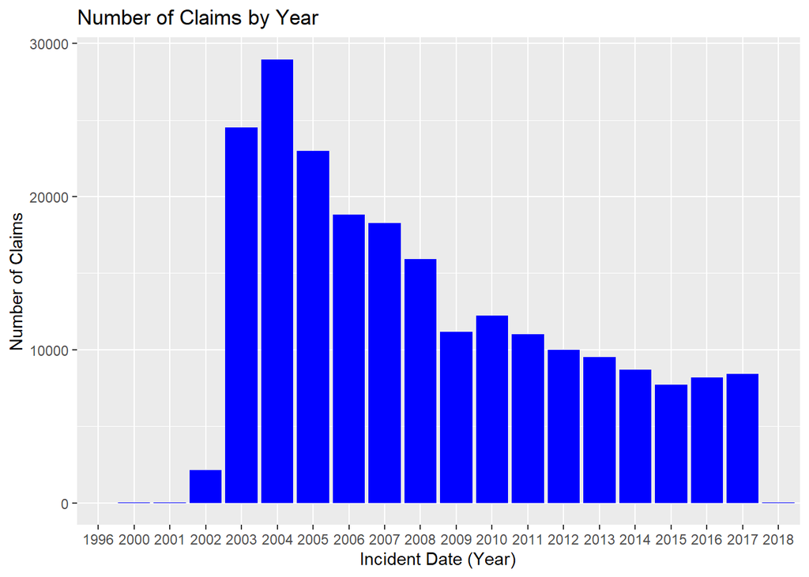

```r
library(ggplot2)

castbl_tsa_year <- defCasTable(s, "tsaclaims_cleaned_freq_date")
casdf_tsa_year <- to.casDataFrame(castbl_tsa_year, obs=nrow(castbl_tsa_year))
casdf_tsa_year <- clean_names(casdf_tsa_year)
df_tsa_year = data.frame(casdf_tsa_year)
df_tsa_year <- filter(df_tsa_year, numvar!="NaN")

ggplot(data=df_tsa_year, aes(x=fmtvar, y=frequency)) +
  geom_col(fill="blue") +
  labs(x='Incident Date (Year)',
       y='Number of Claims',
       title='Number of Claims by Year')
```

Here the ggplot function is used multiple times to create bar charts showing the number of claims by claim site, claim type, and disposition.

### By Claim Site

```r
cas.simple.freq(s,
                table=list(caslib="casuser",
                           name="tsaclaims_cleaned",
                           where="StateName='Hawaii' and Date_Issues is null"),
                inputs=list("Claim_Site"),
                casOut=list(caslib="casuser",
                            name="tsaclaims_cleaned_freq_claimsite",
                            replace=TRUE))
```

```
## $OutputCasTables
##            casLib                             Name Rows Columns
## 1 CASUSER(gazhan) tsaclaims_cleaned_freq_claimsite    6       5
```

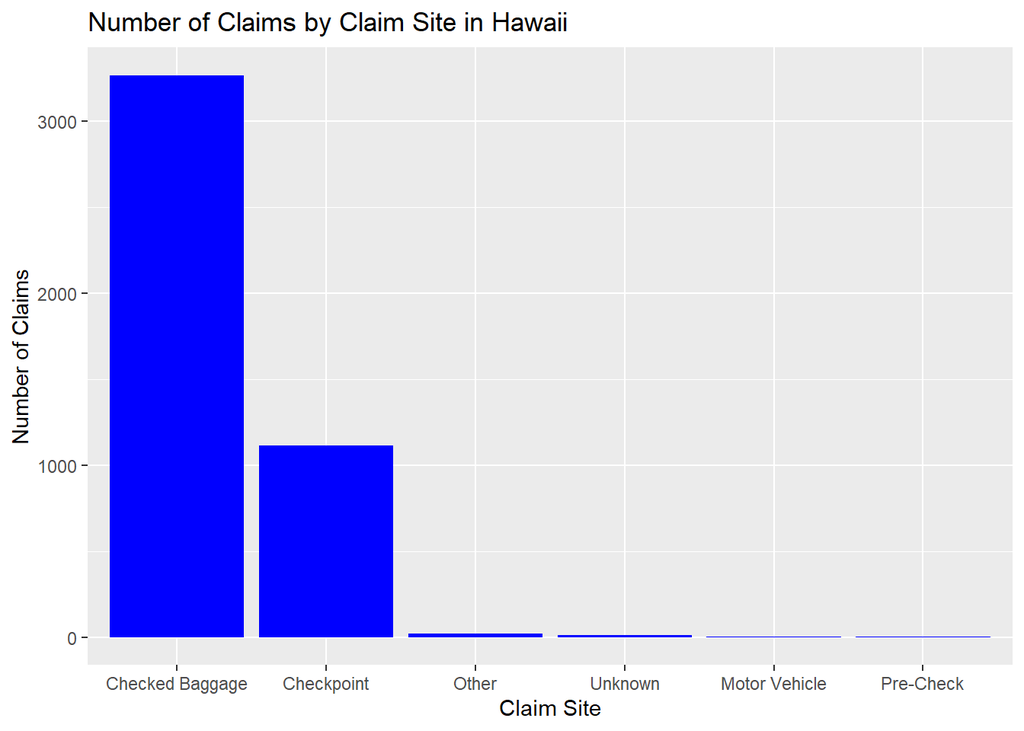

```r
castbl_tsa_claim_site <- defCasTable(s, "tsaclaims_cleaned_freq_claimsite")
casdf_tsa_claim_site <- to.casDataFrame(castbl_tsa_claim_site, obs=nrow(castbl_tsa_claim_site))
casdf_tsa_claim_site <- clean_names(casdf_tsa_claim_site)
df_tsa_claim_site <- data.frame(casdf_tsa_claim_site)

ggplot(data=df_tsa_claim_site, aes(x=reorder(fmtvar, -frequency), y=frequency)) +
  geom_col(fill="blue") +
  labs(x='Claim Site',
       y='Number of Claims',
       title='Number of Claims by Claim Site in Hawaii')
```

### By Claim Type

```r
cas.simple.freq(s,
                table=list(caslib="casuser",
                           name="tsaclaims_cleaned",
                           where="StateName='Hawaii' and Date_Issues is null"),
                inputs=list("Claim_Type"),
                casOut=list(caslib="casuser",
                            name="tsaclaims_cleaned_freq_claimtype",
                            replace=TRUE))
```

```
## $OutputCasTables
##            casLib                             Name Rows Columns
## 1 CASUSER(gazhan) tsaclaims_cleaned_freq_claimtype    9       5
```

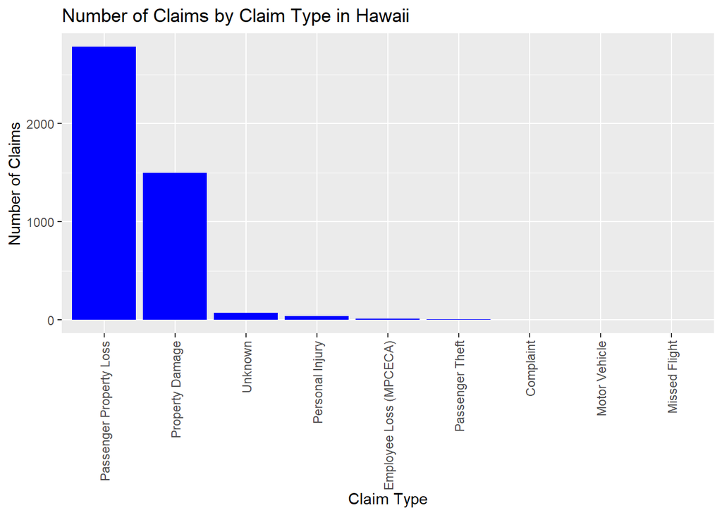

```r
castbl_tsa_claim_type <- defCasTable(s, "tsaclaims_cleaned_freq_claimtype")
casdf_tsa_claim_type <- to.casDataFrame(castbl_tsa_claim_type, obs=nrow(castbl_tsa_claim_type))
casdf_tsa_claim_type <- clean_names(casdf_tsa_claim_type)
df_tsa_claim_type <- data.frame(casdf_tsa_claim_type)

ggplot(data=df_tsa_claim_type, aes(x=reorder(fmtvar, -frequency), y=frequency)) +
  geom_col(fill="blue") +
  labs(x='Claim Type',
       y='Number of Claims',
       title='Number of Claims by Claim Type in Hawaii') +
  theme(axis.text.x = element_text(angle = 90, vjust = 0.5, hjust=1))
```

### By Disposition

```r
cas.simple.freq(s,
                table=list(caslib="casuser",
                           name="tsaclaims_cleaned",
                           where="StateName='Hawaii' and Date_Issues is null"),
                inputs=list("Disposition"),
                casOut=list(caslib="casuser",
                            name="tsaclaims_cleaned_freq_disposition",
                            replace=TRUE))
```

```
## $OutputCasTables
##            casLib                               Name Rows Columns
## 1 CASUSER(gazhan) tsaclaims_cleaned_freq_disposition    7       5
```

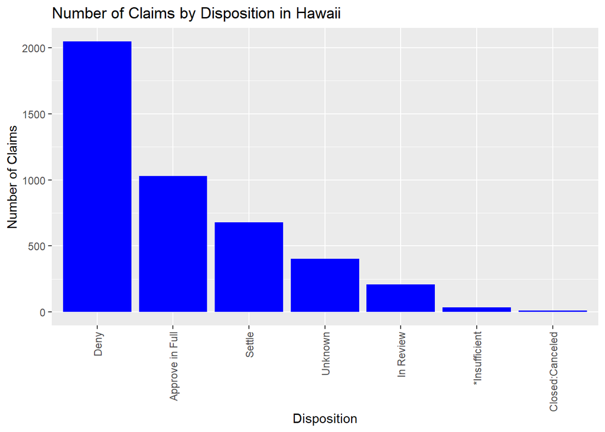

```r
castbl_tsa_disposition <- defCasTable(s, "tsaclaims_cleaned_freq_disposition")
casdf_tsa_disposition <- to.casDataFrame(castbl_tsa_disposition, obs=nrow(castbl_tsa_disposition))
casdf_tsa_disposition <- clean_names(casdf_tsa_disposition)
df_tsa_disposition <- data.frame(casdf_tsa_disposition)

ggplot(data=df_tsa_disposition, aes(x=reorder(fmtvar, -frequency), y=frequency)) +
  geom_col(fill="blue") +
  labs(x='Disposition',
       y='Number of Claims',
       title='Number of Claims by Disposition in Hawaii') +
  theme(axis.text.x = element_text(angle = 90, vjust = 0.5, hjust=1))
```